# Loading Datasets

# Finding the Outliers

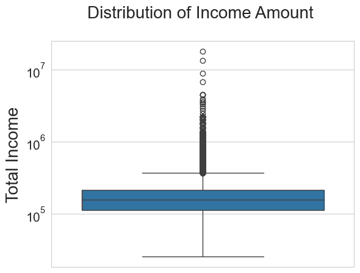

```python
# For Target = 0
# Distribution of Income Amount

sns.set_style('whitegrid')
sns.boxplot(data=target_0, y='AMT_INCOME_TOTAL')
plt.yscale('log')
plt.yticks (fontsize=15)
plt.ylabel("Total Income", fontsize=20)
plt.title('Distribution of Income Amount \n', fontsize=20)
plt.show()
```

### Conclusion from the graph

1. There seems to be an equal distribution of the income amount of the clients
2. Also sone of the outliers present in the dataset

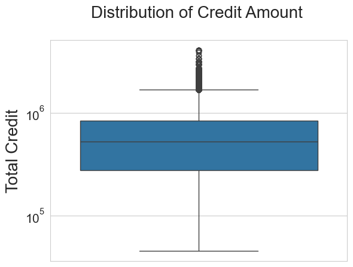

```python
# Distribution of the Credit Amount
sns.set_style('whitegrid')
sns.boxplot(data=target_0, y='AMT_CREDIT')
plt.yscale('log')
plt.yticks (fontsize=15)
plt.ylabel("Total Credit", fontsize=20)
plt.title('Distribution of Credit Amount \n', fontsize=20)
plt.show()
```

Conclusion from graph

1. First quartile is bigger than the third quartile that means most of the clients credit lies in the first-Quartile
2. There seems some outliers in the credit boxplot

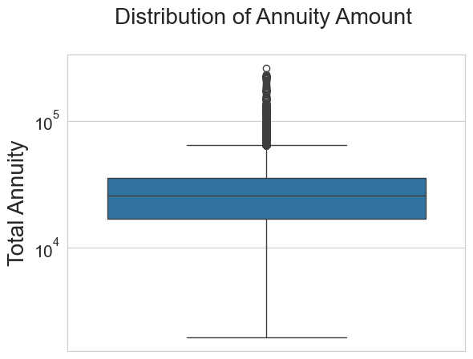

```python
# Distribution of  Annuity
sns.set_style('whitegrid')
sns.boxplot(data=target_0, y='AMT_ANNUITY')
plt.yscale('log')
plt.yticks (fontsize=15)
plt.ylabel("Total Annuity", fontsize=20)
plt.title('Distribution of Annuity Amount \n', fontsize=20)
plt.show()
```

Conclusion from the graph

1. The first Quartile is bigger than the third Quartile
2. There seems some outliers present in the Annuity boxplot

### For Target = 1

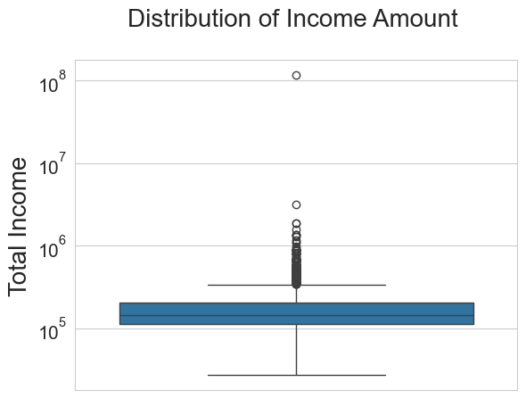

```python
# For Target = 1
# Distribution of Income Amount

sns.set_style('whitegrid')
sns.boxplot(data=target_1, y='AMT_INCOME_TOTAL')
plt.yscale('log')
plt.yticks (fontsize=15)
plt.ylabel("Total Income", fontsize=20)
plt.title('Distribution of Income Amount \n', fontsize=20)
plt.show()
```

Conclusion from the graph

1. There seems to be significant Outliers in the Income boxplot
2. Most of the income lies in the third quartile

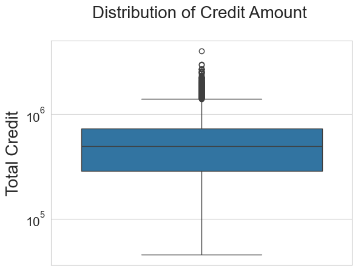

```python
# Distribution of the Credit Amount
sns.set_style('whitegrid')
sns.boxplot(data=target_1, y='AMT_CREDIT')
plt.yscale('log')
plt.yticks (fontsize=15)
plt.ylabel("Total Credit", fontsize=20)
plt.title('Distribution of Credit Amount \n', fontsize=20)
plt.show()
```

Conclusion from the Graph

1. The first quartile is bigger than the third quartile. that means most of the client credit lies in the frst quartile
2. There seems to be outliers present in the Credit BoxPlot

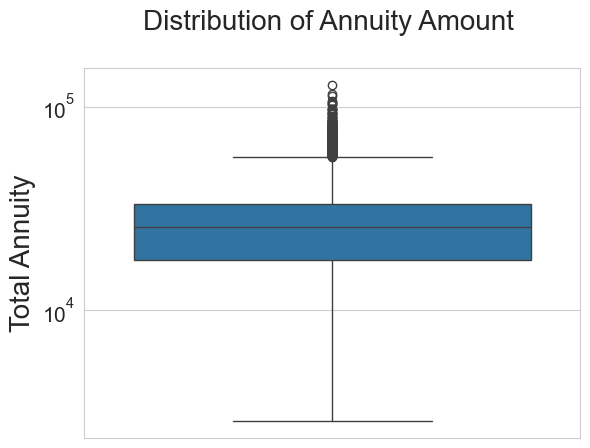

```python
# Distribution of  Annuity
sns.set_style('whitegrid')
sns.boxplot(data=target_1, y='AMT_ANNUITY')
plt.yscale('log')
plt.yticks (fontsize=15)
plt.ylabel("Total Annuity", fontsize=20)
plt.title('Distribution of Annuity Amount \n', fontsize=20)
plt.show()
```

Conclusion from graph

1. The First quartile is bigger than the third quartile
2. There seems some outliers in the Annuity boxplot

## Multivariate Analysis

### Target = 0

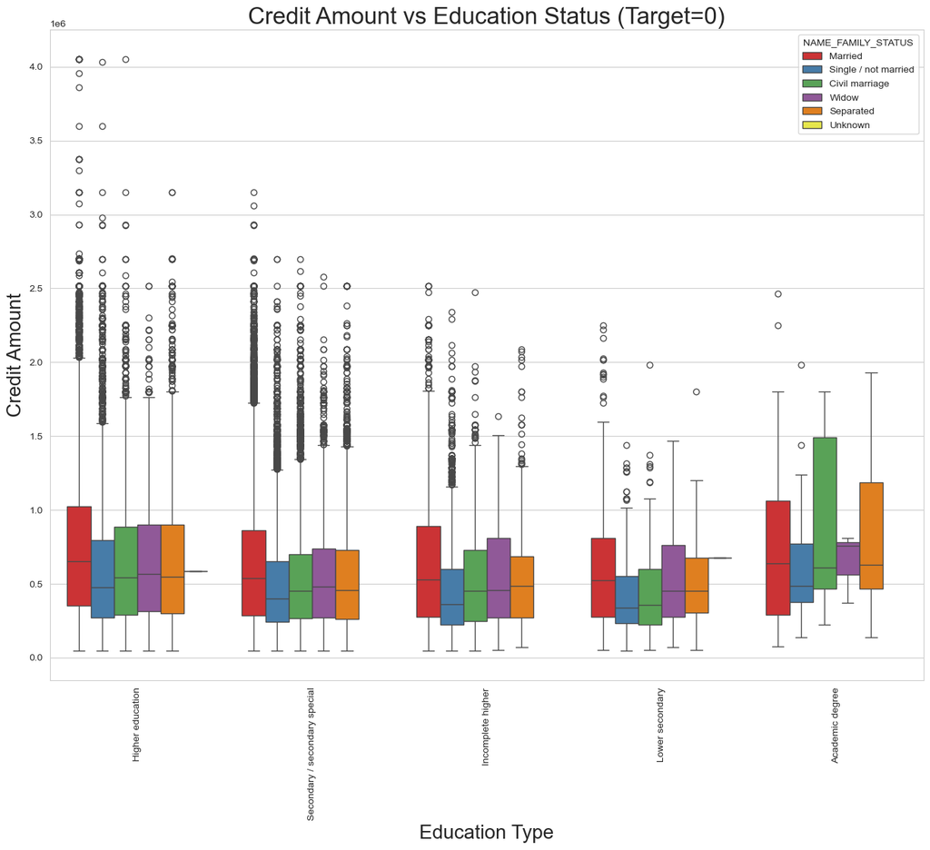

```python
# Box Plotting for the Target = 0 , Credit Amount

plt.figure(figsize=[16, 12])

# Boxplot
sns.boxplot(data=target_0,
            x='NAME_EDUCATION_TYPE',
            y='AMT_CREDIT',
            hue='NAME_FAMILY_STATUS',
            palette='Set1')

# Adjusting aesthetics
plt.xticks(rotation=90)
plt.xlabel('Education Type', fontsize=20)
plt.ylabel('Credit Amount', fontsize=20)
plt.title('Credit Amount vs Education Status (Target=0)', fontsize=24)

# Display the plot
plt.show()
```

### Conclusion from graph

1. Form the above box plot we can conclude that Family Status of 'civil marriage', 'marriage' and 'seperated' of Academic degree education are having higher number of credits than others . Also, higher education of family status of 'marriage'. 'single','civil marriage' are having more outliers
2. Civil Marriage for Academic degree id having most of the credits in the third quartile

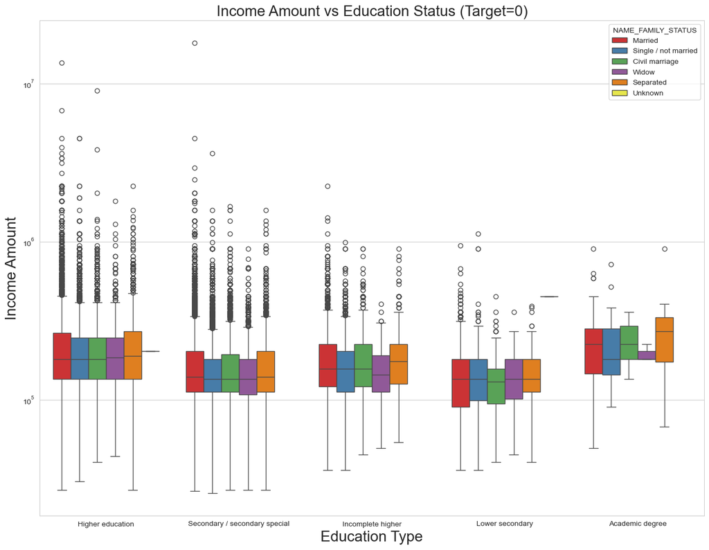

```python
# Box Plot ting for the Target = 0, Income Amount
plt.figure(figsize=[16,12])

# Boxplot
sns.boxplot(data=target_0,
            x='NAME_EDUCATION_TYPE',
            y='AMT_INCOME_TOTAL',
            hue='NAME_FAMILY_STATUS',
            palette='Set1')

# Adjusting aesthetics
plt.xticks(rotation=0)
plt.xlabel('Education Type', fontsize=20)
plt.ylabel('Income Amount', fontsize=20)
plt.yscale('log')
plt.title('Income Amount vs Education Status (Target=0)', fontsize=20)

# Display the plot
plt.show()
```

### Conclusion from graph

From above boxplot for Education type Higher education' the income amount is mostly equal with family status. It does contain many outliers Less outlier are having for Academic degree but there income amount is little higher that Higher education. Lower secondary of civil marriage family status are have less income amount than others.

# Cleaning the Previous_application Dataset

```python
# Previewing the previous_Dataset
df_prev.head(10)
```

|  | SK_ID_PREV | SK_ID_CURR | NAME_CONTRACT_TYPE | AMT_APPLICATION | AMT_CREDIT | WEEKDAY_APPR_PROCESS_START | HOUR_APPR_PROCESS_START | FLAG_LAST_APPL_PER_CONTRACT | NFLAG_LAST_APPL_IN_DAY | NAME_CASH_LOAN_PURPOSE | NAME_CONTRACT_STATUS | DAYS_DECISION | NAME_PAYMENT_TYPE | CODE_REJECT_REASON | NAME_CLIENT_TYPE | NAME_GOODS_CATEGORY | NAME_PORTFOLIO | NAME_PRODUCT_TYPE | CHANNEL_TYPE | SELLERPLACE_AREA | NAME_SELLER_INDUSTRY | NAME_YIELD_GROUP | PRODUCT_COMBINATION |
| --- | --- | --- | --- | --- | --- | --- | --- | --- | --- | --- | --- | --- | --- | --- | --- | --- | --- | --- | --- | --- | --- | --- | --- |
| 0 | 2030495 | 271877 | Consumer loans | 17145.0 | 17145.0 | SATURDAY | 15 | Y | 1 | XAP | Approved | -73 | Cash through the bank | XAP | Repeater | Mobile | POS | XNA | Country-wide | 35 | Connectivity | middle | POS mobile with interest |
| 1 | 2802425 | 108129 | Cash loans | 607500.0 | 679671.0 | THURSDAY | 11 | Y | 1 | XNA | Approved | -164 | XNA | XAP | Repeater | XNA | Cash | x-sell | Contact center | -1 | XNA | low_action | Cash X-Sell: low |
| 2 | 2523466 | 122040 | Cash loans | 112500.0 | 136444.5 | TUESDAY | 11 | Y | 1 | XNA | Approved | -301 | Cash through the bank | XAP | Repeater | XNA | Cash | x-sell | Credit and cash offices | -1 | XNA | high | Cash X-Sell: high |
| 3 | 2819243 | 176158 | Cash loans | 450000.0 | 470790.0 | MONDAY | 7 | Y | 1 | XNA | Approved | -512 | Cash through the bank | XAP | Repeater | XNA | Cash | x-sell | Credit and cash offices | -1 | XNA | middle | Cash X-Sell: middle |
| 4 | 1784265 | 202054 | Cash loans | 337500.0 | 404055.0 | THURSDAY | 9 | Y | 1 | Repairs | Refused | -781 | Cash through the bank | HC | Repeater | XNA | Cash | walk-in | Credit and cash offices | -1 | XNA | high | Cash Street: high |
| 5 | 1383531 | 199383 | Cash loans | 315000.0 | 340573.5 | SATURDAY | 8 | Y | 1 | Everyday expenses | Approved | -684 | Cash through the bank | XAP | Repeater | XNA | Cash | x-sell | Credit and cash offices | -1 | XNA | low_normal | Cash X-Sell: low |
| 6 | 2315218 | 175704 | Cash loans | 0.0 | 0.0 | TUESDAY | 11 | Y | 1 | XNA | Canceled | -14 | XNA | XAP | Repeater | XNA | XNA | XNA | Credit and cash offices | -1 | XNA | XNA | Cash |
| 7 | 1656711 | 296299 | Cash loans | 0.0 | 0.0 | MONDAY | 7 | Y | 1 | XNA | Canceled | -21 | XNA | XAP | Repeater | XNA | XNA | XNA | Credit and cash offices | -1 | XNA | XNA | Cash |
| 8 | 2367563 | 342292 | Cash loans | 0.0 | 0.0 | MONDAY | 15 | Y | 1 | XNA | Canceled | -386 | XNA | XAP | Repeater | XNA | XNA | XNA | Credit and cash offices | -1 | XNA | XNA | Cash |
| 9 | 2579447 | 334349 | Cash loans | 0.0 | 0.0 | SATURDAY | 15 | Y | 1 | XNA | Canceled | -57 | XNA | XAP | Repeater | XNA | XNA | XNA | Credit and cash offices | -1 | XNA | XNA | Cash |

```python
# Analyzing the shape
df_prev.shape
```

```
(1670214, 23)
```

```python
# Checking the Null values in the Dataset
round((100*df_prev.isnull().sum()/len(df_prev)),2)
```

```
SK_ID_PREV                     0.00
SK_ID_CURR                     0.00
NAME_CONTRACT_TYPE             0.00
AMT_APPLICATION                0.00
AMT_CREDIT                     0.00
WEEKDAY_APPR_PROCESS_START     0.00
HOUR_APPR_PROCESS_START        0.00
FLAG_LAST_APPL_PER_CONTRACT    0.00
NFLAG_LAST_APPL_IN_DAY         0.00
NAME_CASH_LOAN_PURPOSE         0.00
NAME_CONTRACT_STATUS           0.00
DAYS_DECISION                  0.00
NAME_PAYMENT_TYPE              0.00
CODE_REJECT_REASON             0.00
NAME_CLIENT_TYPE               0.00
NAME_GOODS_CATEGORY            0.00
NAME_PORTFOLIO                 0.00
NAME_PRODUCT_TYPE              0.00
CHANNEL_TYPE                   0.00
SELLERPLACE_AREA               0.00
NAME_SELLER_INDUSTRY           0.00
NAME_YIELD_GROUP               0.00
PRODUCT_COMBINATION            0.02
dtype: float64
```

```python
# Checking the NA.ME_CASH_LOAN_PURPOSE for any unique values
df_prev.NAME_CASH_LOAN_PURPOSE.value_counts()
```

```
NAME_CASH_LOAN_PURPOSE
XAP                                 922661
XNA                                 677918
Repairs                              23765
Other                                15608
Urgent needs                          8412
Buying a used car                     2888
Building a house or an annex          2693
Everyday expenses                     2416
Medicine                              2174
Payments on other loans               1931
Education                             1573
Journey                               1239
Purchase of electronic equipment      1061
Buying a new car                      1012
Wedding / gift / holiday               962
Buying a home                          865
Car repairs                            797
Furniture                              749
Buying a holiday home / land           533
Business development                   426
Gasification / water supply            300
Buying a garage                        136
Hobby                                   55
Money for a third person                25
Refusal to name the goal                15
Name: count, dtype: int64
```

```python
# We Got two Unknown Columns in our Dataset 'XAP' and 'XNA' We have to drop
df_prev = df_prev.drop(df_prev[df_prev.NAME_CASH_LOAN_PURPOSE == 'XAP'].index)
df_prev = df_prev.drop(df_prev[df_prev.NAME_CASH_LOAN_PURPOSE == 'XNA'].index)
```

```python
# ReChecking the NAME_CASH_LOAN_PURPOSE for any unique values
df_prev.NAME_CASH_LOAN_PURPOSE.value_counts()
```

```
NAME_CASH_LOAN_PURPOSE
Repairs                             23765
Other                               15608
Urgent needs                         8412
Buying a used car                    2888
Building a house or an annex         2693
Everyday expenses                    2416
Medicine                             2174
Payments on other loans              1931
Education                            1573
Journey                              1239
Purchase of electronic equipment     1061
Buying a new car                     1012
Wedding / gift / holiday              962
Buying a home                         865
Car repairs                           797
Furniture                             749
Buying a holiday home / land          533
Business development                  426
Gasification / water supply           300
Buying a garage                       136
Hobby                                  55
Money for a third person               25
Refusal to name the goal               15
Name: count, dtype: int64
```

# Merging both Dataset i.e application_dataset and Previous_dataset

```python
# Merging the Two Datasets
loan_data = pd.merge(left=df_app, right=df_prev, how='inner', on='SK_ID_CURR', suffixes=('_','x'))
```

```python
# Previewing the new Datset
loan_data.head(10)
```

|  | SK_ID_CURR | TARGET | NAME_CONTRACT_TYPE_ | CODE_GENDER | FLAG_OWN_CAR | FLAG_OWN_REALTY | CNT_CHILDREN | AMT_INCOME_TOTAL | AMT_CREDIT_ | AMT_ANNUITY | AMT_GOODS_PRICE | NAME_TYPE_SUITE | NAME_INCOME_TYPE | NAME_EDUCATION_TYPE | NAME_FAMILY_STATUS | NAME_HOUSING_TYPE | REGION_POPULATION_RELATIVE | DAYS_BIRTH | DAYS_EMPLOYED | DAYS_REGISTRATION | DAYS_ID_PUBLISH | OWN_CAR_AGE | OCCUPATION_TYPE | CNT_FAM_MEMBERS | WEEKDAY_APPR_PROCESS_START_ | HOUR_APPR_PROCESS_START_ | REG_REGION_NOT_LIVE_REGION | REG_REGION_NOT_WORK_REGION | LIVE_REGION_NOT_WORK_REGION | … |
| --- | --- | --- | --- | --- | --- | --- | --- | --- | --- | --- | --- | --- | --- | --- | --- | --- | --- | --- | --- | --- | --- | --- | --- | --- | --- | --- | --- | --- | --- | --- |
| 0 | 100034 | 0 | Revolving loans | M | N | Y | 0 | 90000.0 | 180000.0 | 9000.0 | 180000.0 | Unaccompanied | Working | Higher education | Single / not married | With parents | 0.030755 | -10341 | -1010 | -4799 | -3015 | NaN | Laborers | 1.0 | TUESDAY | 16 | 0 | 0 | 0 | … |
| 1 | 100035 | 0 | Cash loans | F | N | Y | 0 | 292500.0 | 665892.0 | 24592.5 | 477000.0 | Unaccompanied | Commercial associate | Secondary / secondary special | Civil marriage | House / apartment | 0.025164 | -15280 | -2668 | -5266 | -3787 | NaN | NaN | 2.0 | WEDNESDAY | 13 | 0 | 0 | 0 | … |
| 2 | 100039 | 0 | Cash loans | M | Y | N | 1 | 360000.0 | 733315.5 | 39069.0 | 679500.0 | Unaccompanied | Commercial associate | Secondary / secondary special | Married | House / apartment | 0.015221 | -11694 | -2060 | -3557 | -3557 | 3.0 | Drivers | 3.0 | THURSDAY | 10 | 0 | 0 | 0 | … |
| 3 | 100046 | 0 | Revolving loans | M | Y | Y | 0 | 180000.0 | 540000.0 | 27000.0 | 540000.0 | Unaccompanied | Working | Higher education | Married | House / apartment | 0.025164 | -16126 | -1761 | -8236 | -4292 | 3.0 | Managers | 2.0 | TUESDAY | 8 | 0 | 0 | 0 | … |
| 4 | 100046 | 0 | Revolving loans | M | Y | Y | 0 | 180000.0 | 540000.0 | 27000.0 | 540000.0 | Unaccompanied | Working | Higher education | Married | House / apartment | 0.025164 | -16126 | -1761 | -8236 | -4292 | 3.0 | Managers | 2.0 | TUESDAY | 8 | 0 | 0 | 0 | … |
| 5 | 100060 | 0 | Cash loans | M | Y | N | 0 | 76500.0 | 454500.0 | 14661.0 | 454500.0 | Unaccompanied | Working | Secondary / secondary special | Married | House / apartment | 0.028663 | -12282 | -778 | -1824 | -1992 | 13.0 | NaN | 2.0 | TUESDAY | 10 | 0 | 0 | 0 | … |
| 6 | 100063 | 0 | Cash loans | F | N | Y | 0 | 180000.0 | 837427.5 | 45558.0 | 666000.0 | Unaccompanied | Working | Higher education | Married | House / apartment | 0.022625 | -12955 | -4106 | -7054 | -5164 | NaN | Managers | 2.0 | MONDAY | 15 | 0 | 0 | 0 | … |
| 7 | 100063 | 0 | Cash loans | F | N | Y | 0 | 180000.0 | 837427.5 | 45558.0 | 666000.0 | Unaccompanied | Working | Higher education | Married | House / apartment | 0.022625 | -12955 | -4106 | -7054 | -5164 | NaN | Managers | 2.0 | MONDAY | 15 | 0 | 0 | 0 | … |
| 8 | 100063 | 0 | Cash loans | F | N | Y | 0 | 180000.0 | 837427.5 | 45558.0 | 666000.0 | Unaccompanied | Working | Higher education | Married | House / apartment | 0.022625 | -12955 | -4106 | -7054 | -5164 | NaN | Managers | 2.0 | MONDAY | 15 | 0 | 0 | 0 | … |
| 9 | 100077 | 0 | Cash loans | M | N | Y | 0 | 180000.0 | 1256400.0 | 40657.5 | 900000.0 | Unaccompanied | Commercial associate | Secondary / secondary special | Single / not married | House / apartment | 0.072508 | -12049 | -579 | -6105 | -1 | NaN | Core staff | 1.0 | WEDNESDAY | 12 | 0 | 0 | 0 | … |

```python
loan_data.info()
```

```
<class 'pandas.core.frame.DataFrame'>
RangeIndex: 51420 entries, 0 to 51419
Columns: 116 entries, SK_ID_CURR to PRODUCT_COMBINATION
dtypes: category(1), float64(59), int64(25), object(31)
memory usage: 45.2+ MB
```

```python
# Renaming the Columns in the new Dataset Loan_data
loan_data = loan_data.rename({'NAME_CONTRACT_TYPE_': 'NAME_CONTRACT_TYPE', 'AMT_CREDIT_':'AMT_CREDIT', 'AMT_ANNUITY_': 'AMT_ANNUITY',
                                'WEEKDAY_APPR_PROCESS_START_': 'WEEKDAY_APPR_PROCESS_START', 'HOUR_APPR_PROCESS_START_': 'HOUR_APPR_PROCESS_START',
                                'NAME_CONTRACT_TYPEx': 'NAME_CONTRACT_TYPE_PREV', 'AMT_CREDITx': 'AMT_CREDIT_PREV', 'AMT_ANNUITYx': 'AMT_ANNUITY_PREV',
                                'WEEKDAY_APPR_PROCESS_STARTx': 'WEEKDAY_APPR_PROCESS_START_PREV', 'HOUR_APPR_PROCESS_STARTx': 'HOUR_APPR_PROCESS_START_PREV'},
                                axis=1)
```

```python
loan_data.info()
```

```
<class 'pandas.core.frame.DataFrame'>
RangeIndex: 51420 entries, 0 to 51419
Columns: 116 entries, SK_ID_CURR to PRODUCT_COMBINATION
dtypes: category(1), float64(59), int64(25), object(31)
memory usage: 45.2+ MB
```

```python
# Droping the Unwanted columns
loan_data.drop(['SK_ID_CURR', 'WEEKDAY_APPR_PROCESS_START', 'HOUR_APPR_PROCESS_START', 'REG_REGION_NOT_LIVE_REGION', 'REG_REGION_NOT_WORK_REGION',
           'LIVE_REGION_NOT_WORK_REGION', 'REG_CITY_NOT_LIVE_CITY', 'REG_CITY_NOT_WORK_CITY', 'LIVE_CITY_NOT_WORK_CITY', 'WEEKDAY_APPR_PROCESS_START_PREV',
           'HOUR_APPR_PROCESS_START_PREV','FLAG_LAST_APPL_PER_CONTRACT', 'NFLAG_LAST_APPL_IN_DAY'], axis=1, inplace=True)
```

```python
loan_data.isnull().sum()
```

```
TARGET                              0
NAME_CONTRACT_TYPE                  0
CODE_GENDER                         0
FLAG_OWN_CAR                        0
FLAG_OWN_REALTY                     0
CNT_CHILDREN                        0
AMT_INCOME_TOTAL                    0
AMT_CREDIT                          0
AMT_ANNUITY                         0
AMT_GOODS_PRICE                     0
NAME_TYPE_SUITE                     0
NAME_INCOME_TYPE                    0
NAME_EDUCATION_TYPE                 0
NAME_FAMILY_STATUS                  0
NAME_HOUSING_TYPE                   0
REGION_POPULATION_RELATIVE          0
DAYS_BIRTH                          0
DAYS_EMPLOYED                       0
DAYS_REGISTRATION                   0
DAYS_ID_PUBLISH                     0
OWN_CAR_AGE                     31898
OCCUPATION_TYPE                  8217
CNT_FAM_MEMBERS                     0
ORGANIZATION_TYPE                   0
EXT_SOURCE_1                    28022
EXT_SOURCE_2                       45
EXT_SOURCE_3                     8542
APARTMENTS_AVG                  26006
BASEMENTAREA_AVG                30140
YEARS_BEGINEXPLUATATION_AVG     24995
YEARS_BUILD_AVG                 34124
COMMONAREA_AVG                  35807
ELEVATORS_AVG                   27191
ENTRANCES_AVG                   25786
FLOORSMAX_AVG                   25562
FLOORSMIN_AVG                   34818
LANDAREA_AVG                    30478
LIVINGAPARTMENTS_AVG            35054
LIVINGAREA_AVG                  25650
NONLIVINGAPARTMENTS_AVG         35590
```

[output cut: 49 more lines]

```
NAME_CASH_LOAN_PURPOSE              0
NAME_CONTRACT_STATUS                0
DAYS_DECISION                       0
NAME_PAYMENT_TYPE                   0
CODE_REJECT_REASON                  0
NAME_CLIENT_TYPE                    0
NAME_GOODS_CATEGORY                 0
NAME_PORTFOLIO                      0
NAME_PRODUCT_TYPE                   0
CHANNEL_TYPE                        0
SELLERPLACE_AREA                    0
NAME_SELLER_INDUSTRY                0
NAME_YIELD_GROUP                    0
PRODUCT_COMBINATION                 0
dtype: int64
```

# UniVariate Analysis

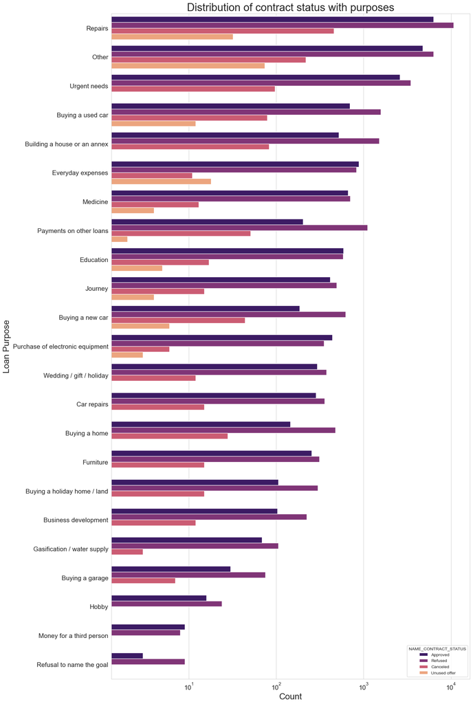

```python
plt.figure(figsize=[15,28])

sns.countplot(data = loan_data, y  = 'NAME_CASH_LOAN_PURPOSE',order=loan_data['NAME_CASH_LOAN_PURPOSE'].value_counts().index, hue='NAME_CONTRACT_STATUS', palette='magma')

plt.title('Distribution of contract status with purposes', fontsize=25)

plt.xticks(fontsize=15)

plt.yticks(fontsize=15)

plt.xlabel('Count', fontsize=20)

plt.ylabel('Loan Purpose', fontsize=20)

plt.xscale('log')
```

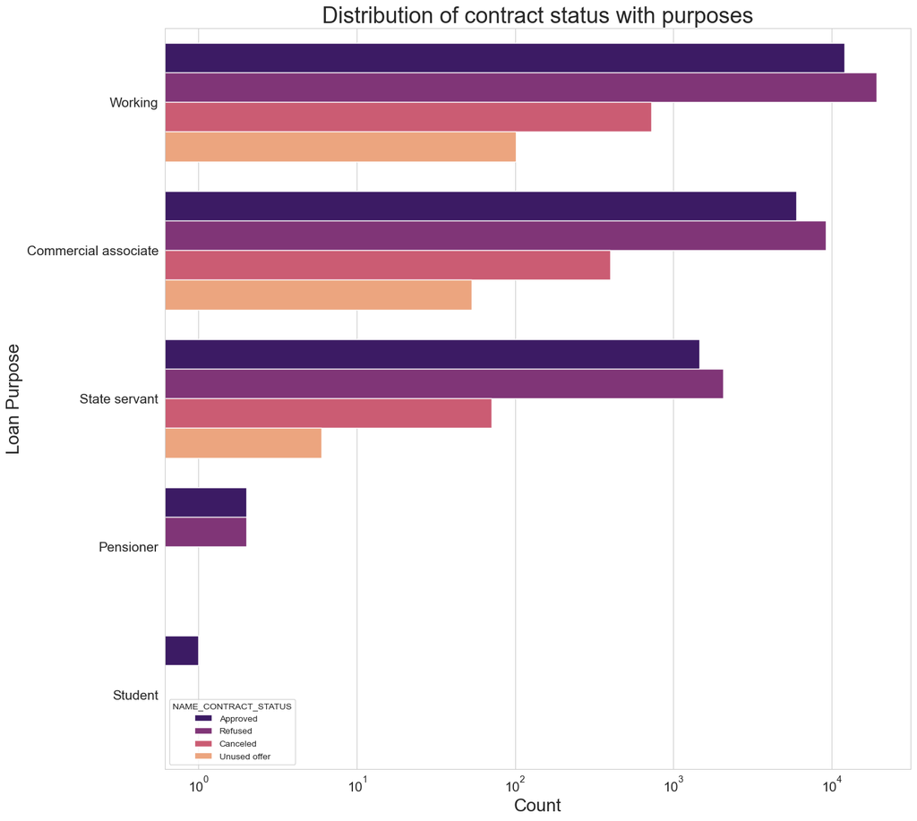

```python
plt.figure(figsize=[15,15])

sns.countplot(data = loan_data, y  = 'NAME_INCOME_TYPE',order=loan_data['NAME_INCOME_TYPE'].value_counts().index, hue='NAME_CONTRACT_STATUS', palette='magma')

plt.title('Distribution of contract status with purposes', fontsize=25)

plt.xticks(fontsize=15)

plt.yticks(fontsize=15)

plt.xlabel('Count', fontsize=20)

plt.ylabel('Loan Purpose', fontsize=20)

plt.xscale('log')
```

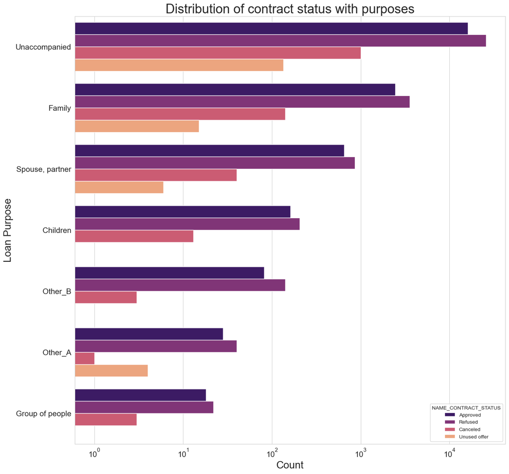

```python
plt.figure(figsize=[15,15])

sns.countplot(data = loan_data, y  = 'NAME_TYPE_SUITE',order=loan_data['NAME_TYPE_SUITE'].value_counts().index, hue='NAME_CONTRACT_STATUS', palette='magma')

plt.title('Distribution of contract status with purposes', fontsize=25)

plt.xticks(fontsize=15)

plt.yticks(fontsize=15)

plt.xlabel('Count', fontsize=20)

plt.ylabel('Loan Purpose', fontsize=20)

plt.xscale('log')
```